# Spatial Data in R: A fast and loose introduction

Steve Fick

June 29th 2016

Some Notes for working with spatial data in R SEI R-users group 6-29-2016

The Rmarkdown file and data used to generate this page is stored on [github](https://github.com/fickse/RSpatial_6-29)

## Goals

Go over some common workflows relevant to members of the group. In particular…

- Getting Data in – importing data from common GIS formats `.shp` and `.tif`
- Basic manipulations – projecting, extracting, cropping, overlay
- Visualization – some tips and tricks for interacting with data
- A (slightly more advanced) discussion of interpolation and cross validation

## Resources

- lets try using [Etherpad](http://etherpad.org/), a tool for collaborative note-taking, during the presentation. Click on the link here, to post comments, notes, and questions throughout the session.
- Data used for the examples are hosted in this repository. The zipped file contains the following:
  - `dem.tif` : an elevation raster for Hawaii
  - `stations.csv`: a csv of climate stations and locations with monthly rainfall
  - `watersheds.shp`: a shapefile of polygons with level 12 watersheds. You can download/unzip the data by hand or run the following code to download and unzip the data to a temporary directory

```r
setwd( tempdir() )  # set working directory to temporary directory
download.file("https://github.com/fickse/RSpatial_6-29/raw/master/data/spdata.zip", destfile = 'spdata.zip')
unzip( 'spdata.zip' , exdir = '.')
```

# 0. Prerequisites

Most of the functions we will use come from the `raster` package. Raster provides some ‘high-level’ interface to spatial data. Also `maps` comes in handy for quick visualization. You can download these packages with…

```r
install.packages('raster', repos = "http://cran.cnr.berkeley.edu/")
```

# 1. Get the data in

```r
library(raster)
```

```r
library(maps)
```

## Loading a raster

```r
dem <- raster('dem.tif')
```

that was easy!

as a side note, raster has a useful function `getData` for downloading commonly used geophysical data including elevation, climate and geopolitical boundaries. The previous dataset could have been loaded with the following:

```r
dem <- getData('alt', country = 'USA')[[4]] # the [[4]] selects the 4th item in the list, which is Hawaii
```

## Loading a shapefile

```r
w <- shapefile('watersheds.shp')
```

also easy!

## Loading points from a csv file

```r
d <- read.csv('stations.csv')

# make d into a SpatialPointsDataFrame
coordinates(d) <- d[,c('lon','lat')]
```

# 2. Visualizations and interaction

## basic plotting

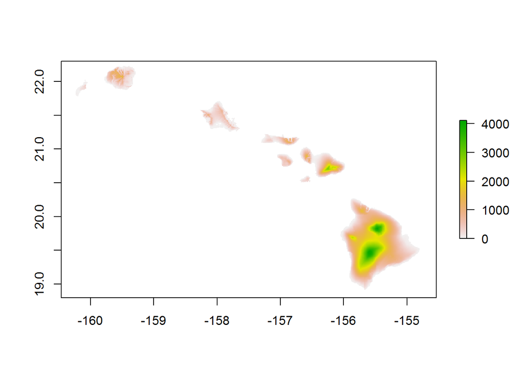

```r
plot(dem)
```

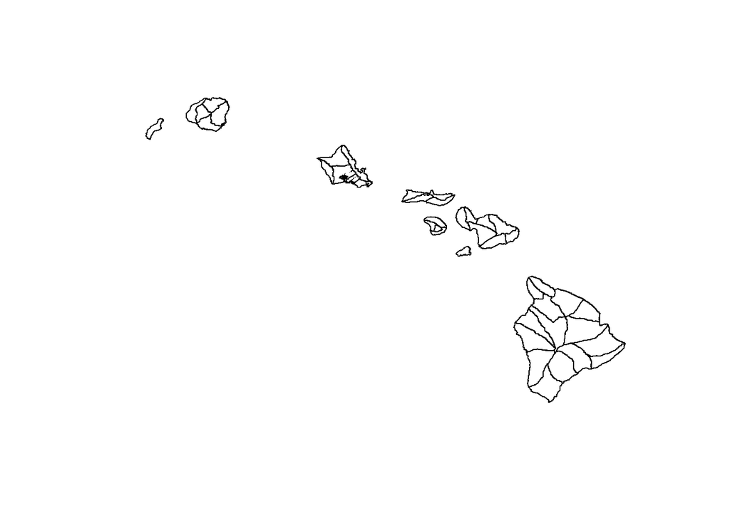

```r
plot(w)
```

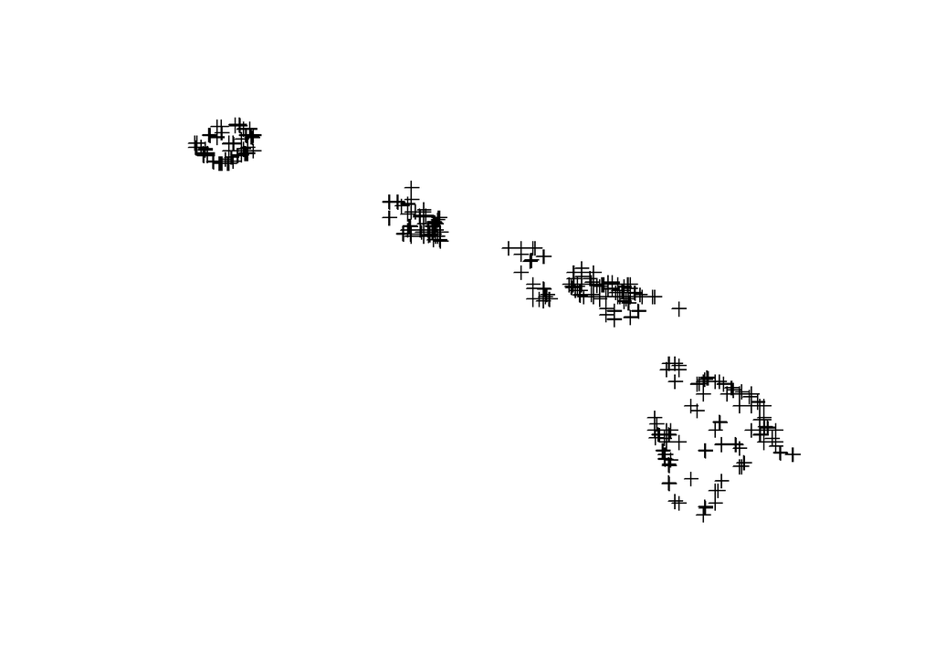

```r
plot(d)
```

## overlaying and coloring

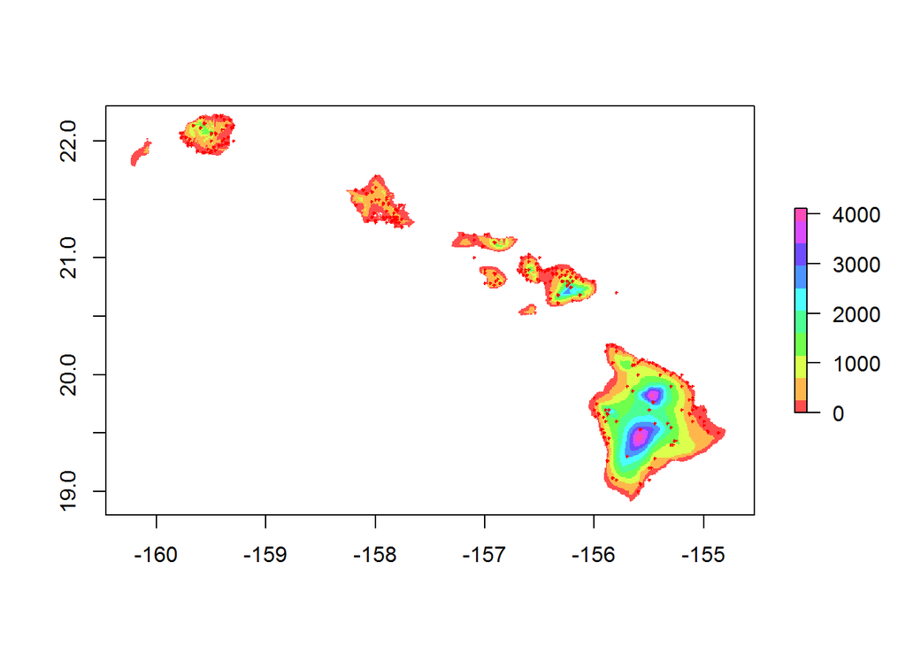

```r
plot(dem, col = rainbow(10, alpha = .7))
plot(d, add = TRUE, col = 'red', cex = .2)
```

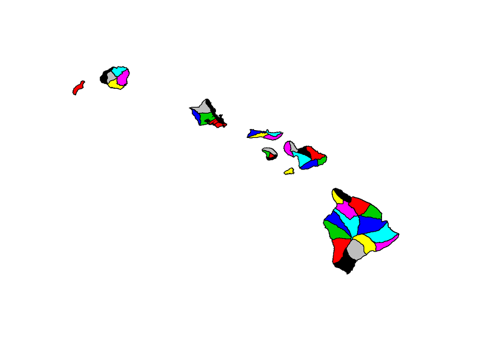

```r
plot(w, col = 1:nrow(w))
```

## zoom

```r
?zoom # make sure to set (new = FALSE) if using Rstudio
```

## drawExtent and crop

If we wanted a new raster that only contained the big island (hawaii), we here’s one way to do it

```r
e <- drawExtent()  # interactively draw a bounding box
bigIsland <- crop(w, e) # use the box to crop spatial element
```

## click

```r
?click
click(d)
click(dem)
```

The following will not turn out well …

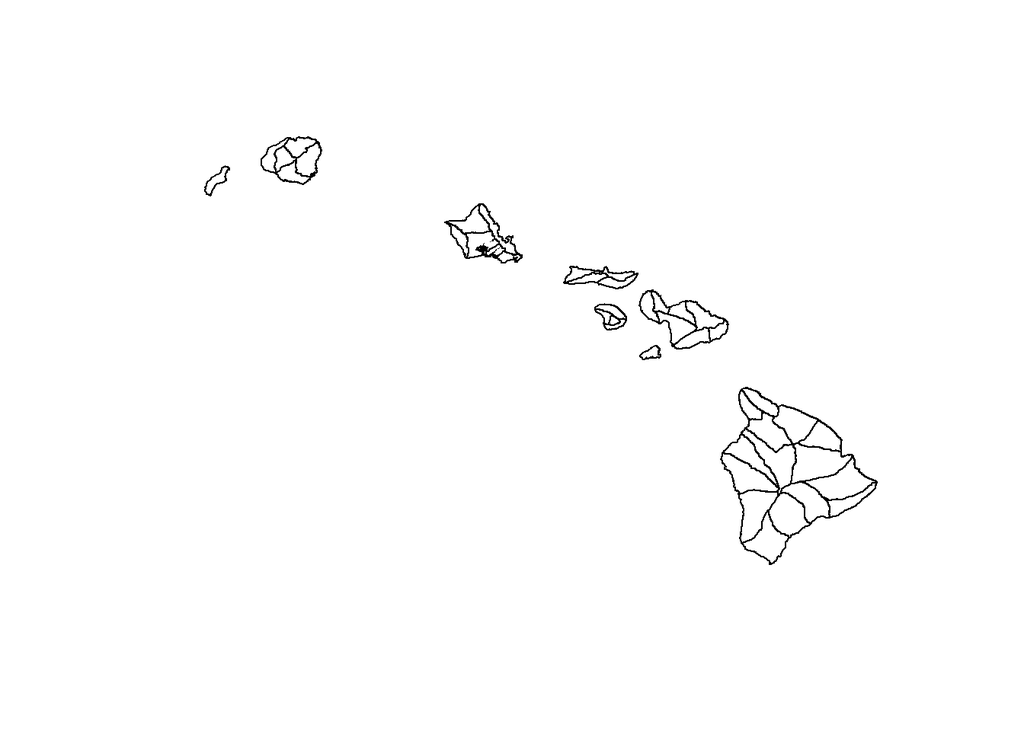

```r
plot(w)
plot(d, add = TRUE, col = 'red', cex = .2)
```

… Where are the stations?!

# 3. Manipulations

## reprojection

Raster provides a nice function to interface with projections.

```r
projection(dem)
```

```
## [1] "+proj=longlat +ellps=WGS84 +no_defs"
```

```r
projection(w)
```

```
## [1] "+proj=tmerc +lat_0=21.83333333333333 +lon_0=-159.5 +k=0.9999900000000001 +x_0=500000 +y_0=0 +datum=NAD83 +units=m +no_defs +ellps=GRS80 +towgs84=0,0,0"
```

```r
projection(d)
```

```
## [1] NA
```

All of the projections are different! Since it is computationally time consuming and generally not ideal to reproject a raster, lets convert the polygons and points to the dem projection…

```r
w <- spTransform(w, projection(dem))
w <- spTransform(w, projection(dem))
```

We know that our station points are in Lon Lat – probably WGS 84. lets quickly double check by plotting

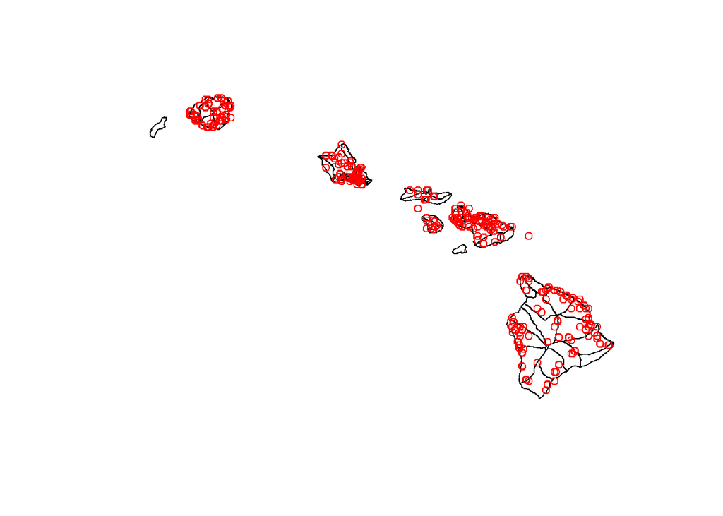

```r
plot(w)
points(d, col = 'red')
```

Ok most points line up with the boundaries – some are clearly errors.

```r
projection(d) <- projection(dem)
```

## Extracting raster information from points

Lets run a quick quality check on our stations

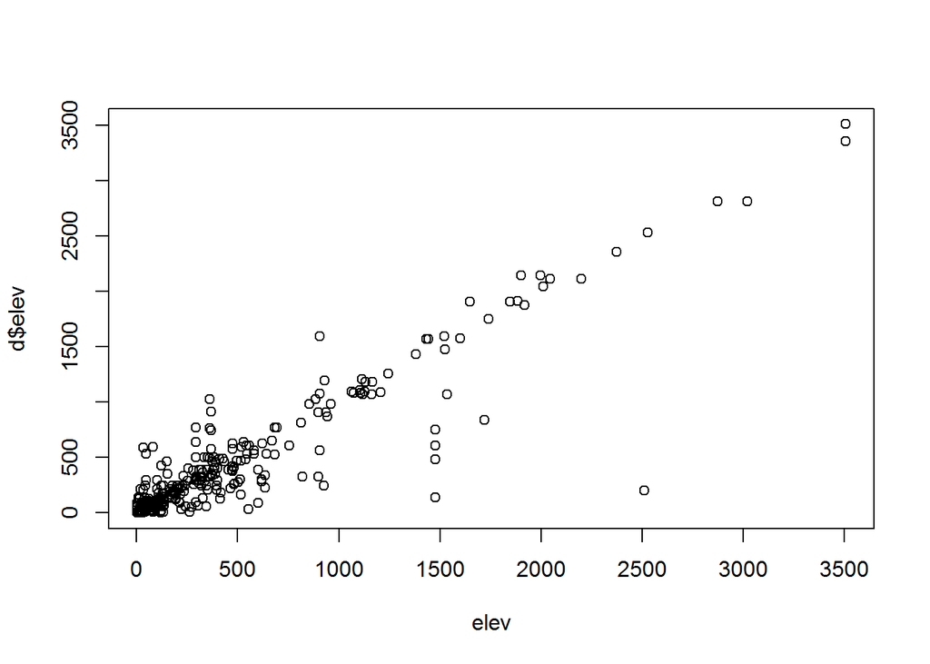

```r
elev <- extract(dem, d)
plot(elev, d$elev)
```

wow some of these stations are way off! lets find points that are > 300 m off of their expected value, or are located in the water

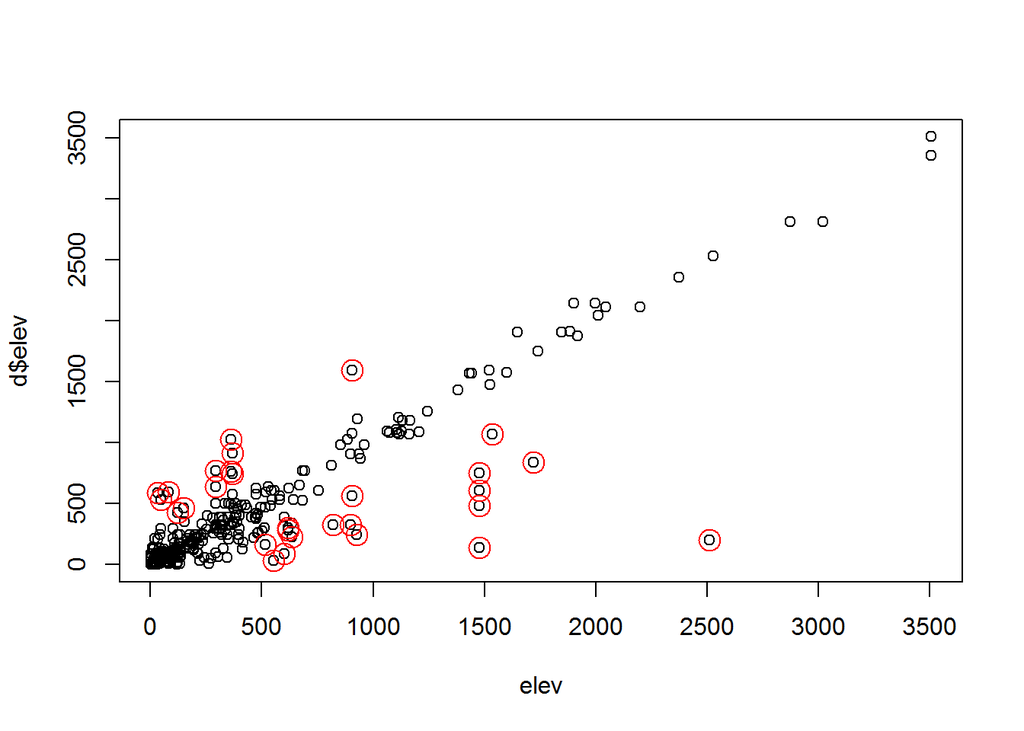

```r
iffyElev <- which(abs(d$elev-elev) > 300 )
inWater <- which(is.na(elev))
bad <- c(iffyElev, inWater)

plot(elev, d$elev)
points(elev[bad],d$elev[bad], col = 'red', cex = 2)
```

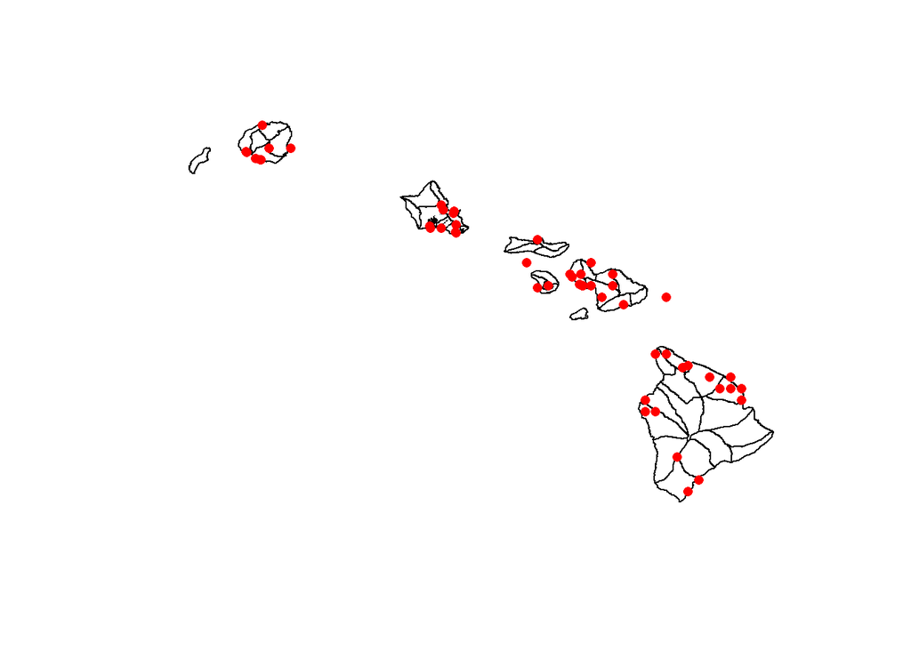

```r
plot(w)
points(d[bad,], col = 'red', cex = 1, pch = 16)
```

```r
# permanently remove
d <- d[-bad,]

# also remove any duplicates

d <- d[ -which( duplicated( coordinates( d))), ]
```

## Calculate slope and or aspect

```r
slope <- terrain(dem, opt = 'slope', unit = 'degrees' )
aspect <- terrain(dem, opt = 'aspect', unit = 'degrees')
```

## Extracting raster information from polygons

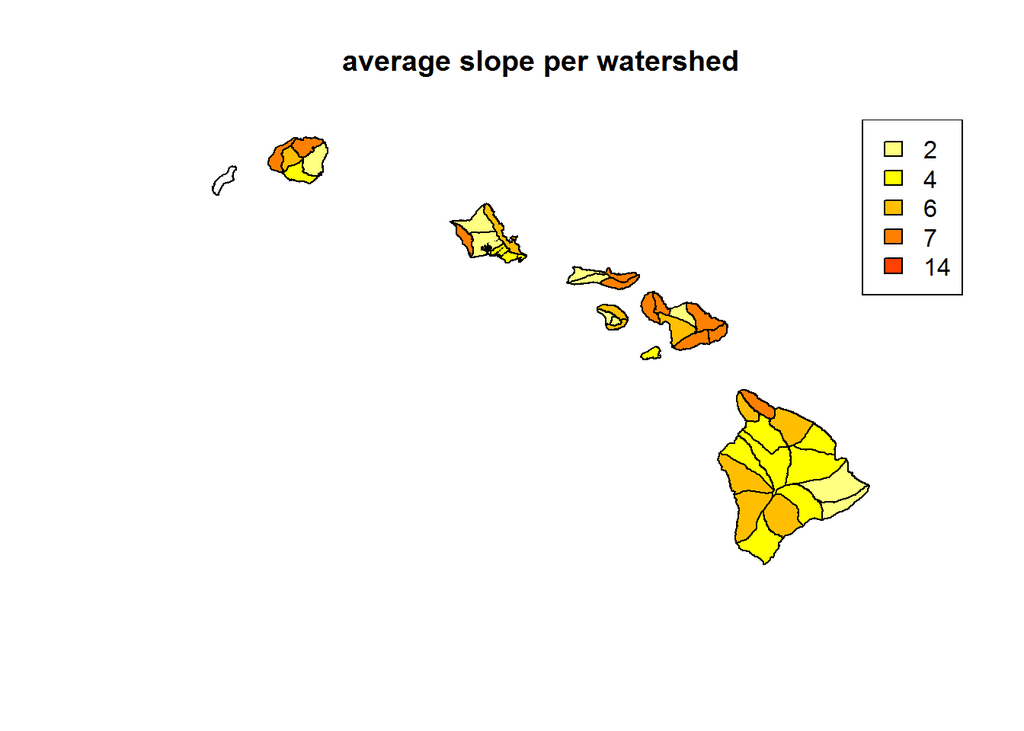

```r
avg_slope <- extract(slope, w, fun = mean, na.rm = TRUE)
w$slope <- avg_slope

#plot it
colors <- rev(heat.colors(6))
breaks <- quantile(avg_slope)

plot(w, col = colors[cut(w$slope, breaks)] , main = 'average slope per watershed')
legend('topright', fill = colors, legend = round(breaks))
```

## Extracting polygon information from points

Which watersheds don’t have any stations?

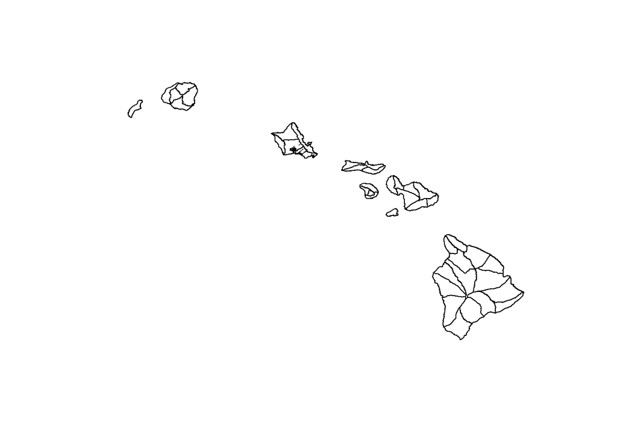

```r
pinfo <- over(d, w)
no_stat <- is.na(pinfo[,1])
plot(w, col = c('white', 'red')[ no_stat + 1] )
```

## Extracting point information from polygons

Which watershed has the most stations?

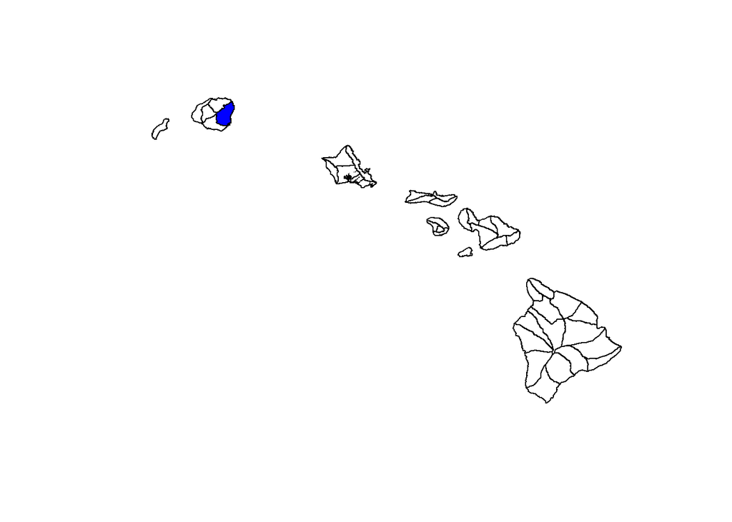

```r
s.info <- over(w,d, returnList = TRUE) # return a list of station info, by polgyon

n.stations <- sapply(s.info , function(x) nrow(x))

most <- which.max(n.stations)

plot(w)
plot(w[most,], col = 'blue', add=TRUE)
```

## Subsetting raster data

plot all areas with elevation above 1000 m and less than 3000 m

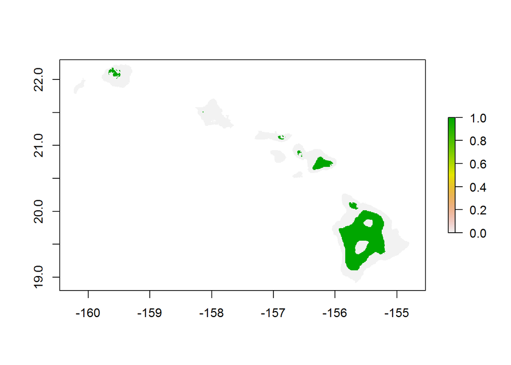

```r
mask <- dem > 1000 & dem < 3000
plot (mask)
```

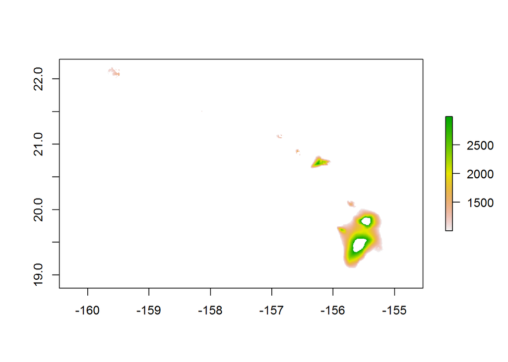

```r
masked <-  mask(dem, mask, maskvalue = 0)
plot(masked)
```

## setting some raster values to NA

```r
length(dem[]) # you can access raster values as a vector with [] - slow for big rasters tho!
```

```
## [1] 282240
```

```r
ncell(dem)
```

```
## [1] 282240
```

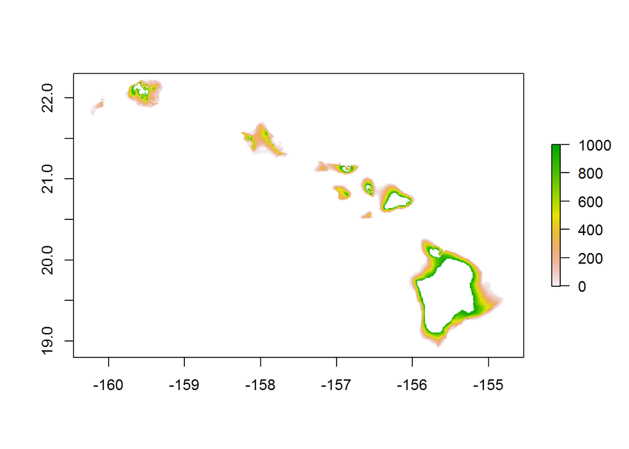

```r
dummy <- dem
dummy[dummy[] > 1000] <- NA
plot(dummy)
```

# 4. Interpolation Excercise

Interpolation is the process of estimating values of a ‘field’ (continuous surface) using values at known locations.

Essentially all spatial interpolation methods are based on Tobler’s first law of geography, which states that

> “everything is related to everything else, but near things are more related than distant things”

Statistical interpolations are often used for creating climate surfaces based on climate station values.

The merits of an interpolation are best evaluated by *cross validation*, that is leaving a portion of data out during model fitting, then comparing predicted results to witheld data.

Lets try interpolating rainfall following the methods outlined in the helpfile for `raster::interpolate`

```r
# aggregate to total average yearly rainfall -- this is what we'll interpolate

y <- rowSums(d@data[, month.abb ])
d$y <-y

# define cross validation groups by randomly subsetting input data. Ideally this process should also take into account distance between witheld data and data used for interpolation -- if they are too near each other our cross validation estimates may appear artificially more accurate.

# we'll withold 20 percent.
test <- sample(1:nrow(d), round (nrow(d) * .2))
```

### Inverse Distance Weighting (IDW)

Inverse distance weighting finds the expected value in a location based on taking a spatially weighted average of neighboring known points. Points that are closer get higher weight.

```r
library(gstat)
  # fit
  mg <- gstat( id = 'y', formula = y~1, data = d[-test,], nmax = 7, set = list(idp = .5))

  #interpolate
  idw.r <- interpolate(dem, mg)
```

```
## [inverse distance weighted interpolation]
```

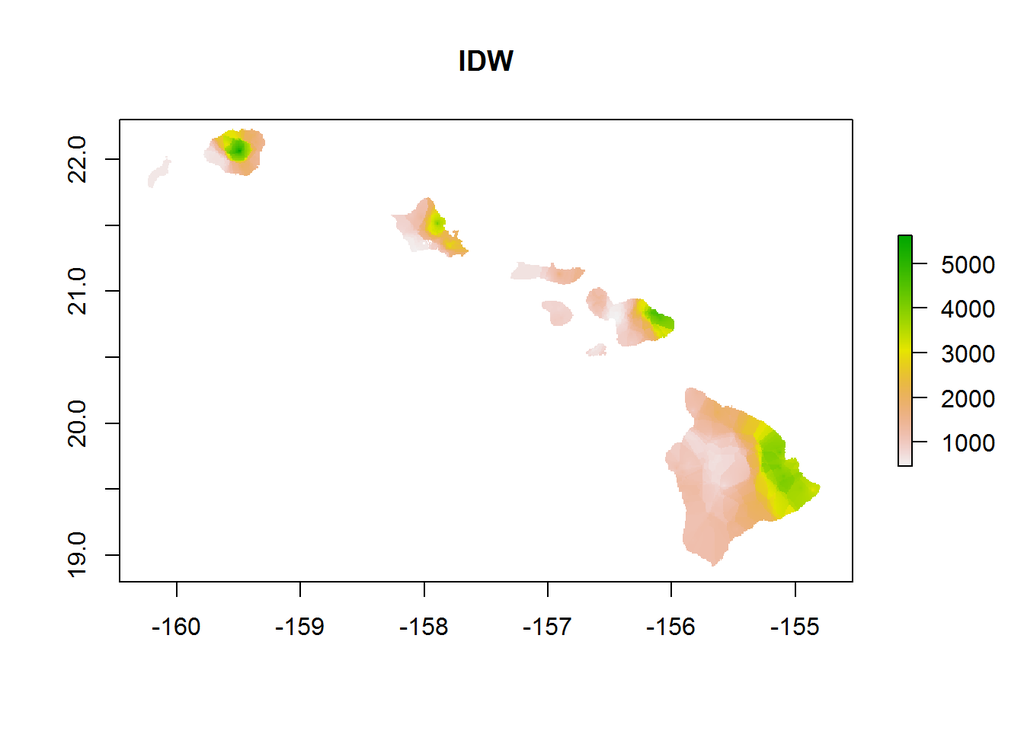

```r
  idw.r <- mask(idw.r, dem)
  plot(idw.r, main = 'IDW')
```

```r
  #evaluate
  idw.p <- predict(mg, d[test,])
```

```
## [inverse distance weighted interpolation]
```

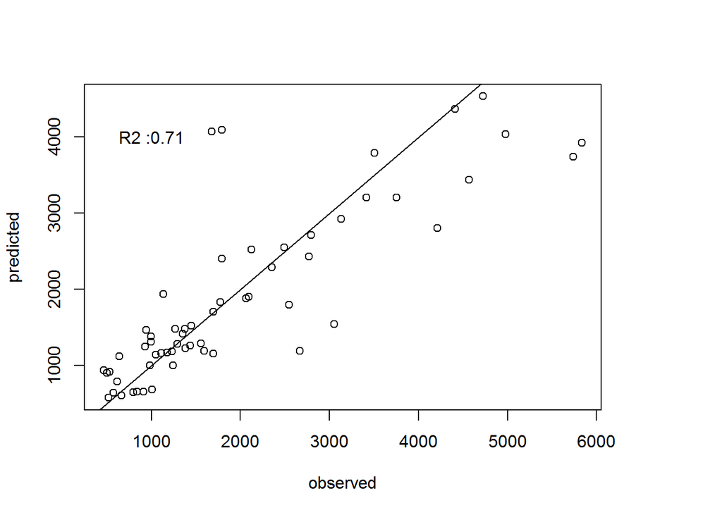

```r
  plot( y[test], idw.p$y.pred, xlab = 'observed', ylab = 'predicted');abline(0,1)
  idw.r2 <- round(cor(idw.p$y.pred, y[test])^2,2)
  text(1000,4000, paste0('R2 :', idw.r2 ))
```

### Thin Plate Splines

First method: *Thin plate spline*. What splines do is try to fit a smooth line that is both close to the data (accurate) and smooth (not-overfit). A tuning parameter “lambda”" determines how smooth or ‘wiggly’ the line is, and lambda is optimized by an algorithm. Example:

```r
library(fields)
```

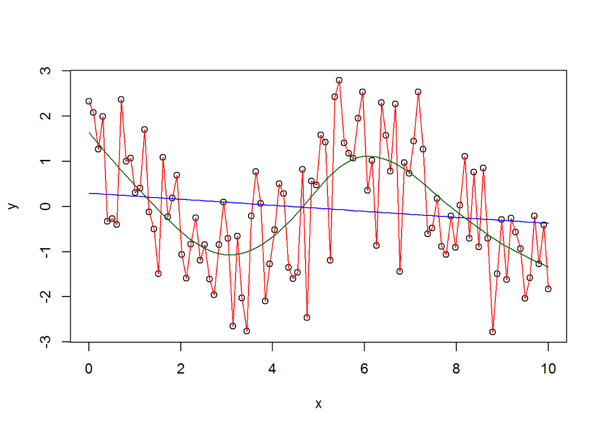

```r
noisy_data <- data.frame( y = rnorm(100) +cos(seq(0,10, length.out = 100)), x = seq(0,10,length.out = 100))
plot(y~ x, data = noisy_data)


#over fit: lambda = 0 -- perfect fit to data but not generalizable
over.fit = Tps(noisy_data$x, noisy_data$y, lambda = 0)
lines( noisy_data$x,predict(over.fit), col = 'red')

#under fit: lambda = 1 -- overly generalized (defaults to linear regression)
under.fit = Tps(noisy_data$x, noisy_data$y, lambda = 1e12)
lines( noisy_data$x,predict(under.fit), col = 'blue')

#optimized -
optimized <- Tps(noisy_data$x, noisy_data$y)
lines( noisy_data$x,predict(optimized), col = 'dark green')
```

For our data, expanded into three dimensions (lat, lon, elevation)

```r
  train <- d@data[-test,]
  testdat <- d@data[test,]

  # fit
  tps <- Tps( train[, c('lon','lat', 'elev')], train$y)
```

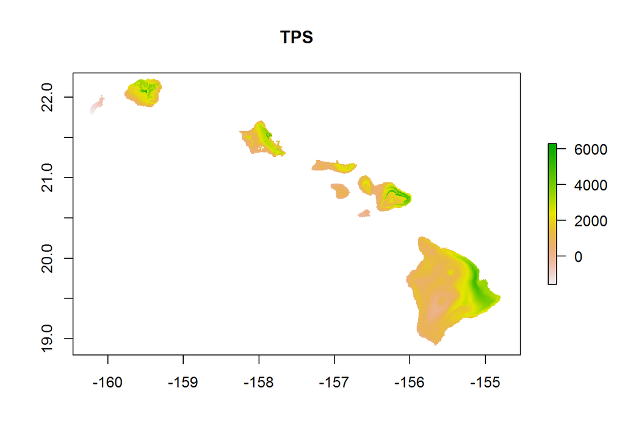

```r
  # interpolate
  tps.r <- interpolate(dem, tps, xyOnly = FALSE)
  plot(tps.r, main='TPS')
```

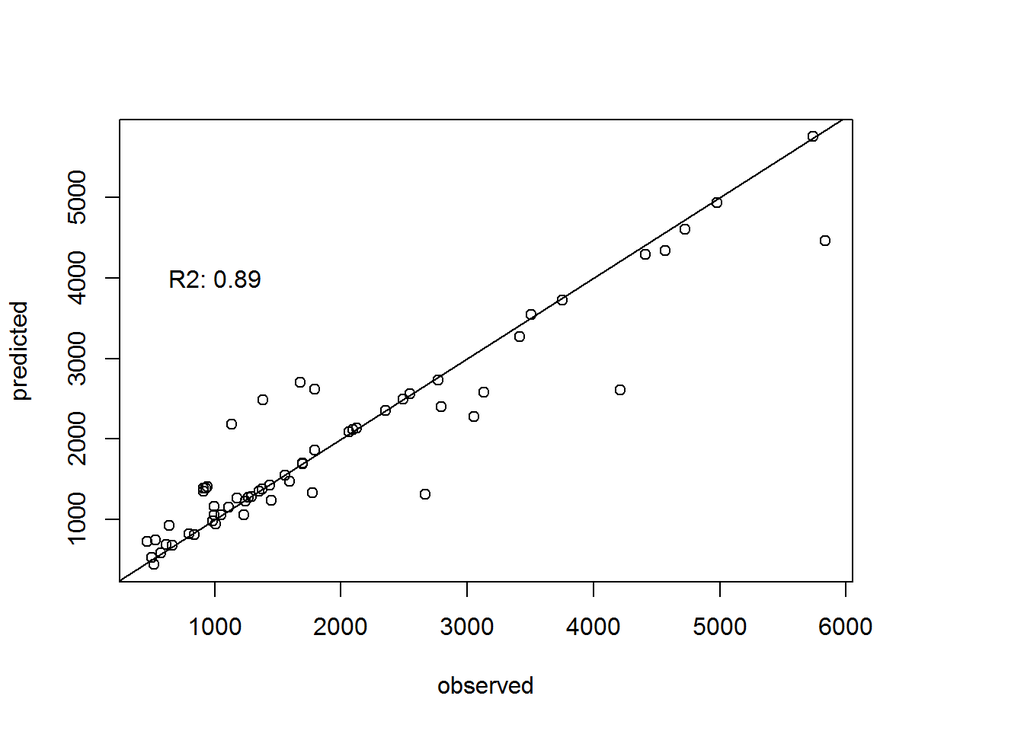

```r
  # evaluate accuracy
  tps.p <- predict(tps, x = testdat[,c('lon','lat','elev')])
  plot( y[test], tps.p, xlab = 'observed', ylab = 'predicted');abline(0,1)
  tps.r2 <- round( cor(tps.p, y[test])^2 , 2)
  text(1000, 4000, paste0('R2: ', tps.r2))
```

### Kriging

Kriging is essentially IDW, except with the weights determined empirically from the data. One plots the average disimilarity between points as a function of distance (a semivariogram), then uses this information to determine how neighboring stations should be weighted.

Universal kriging incorporates linear covariates along with the semivariance function.

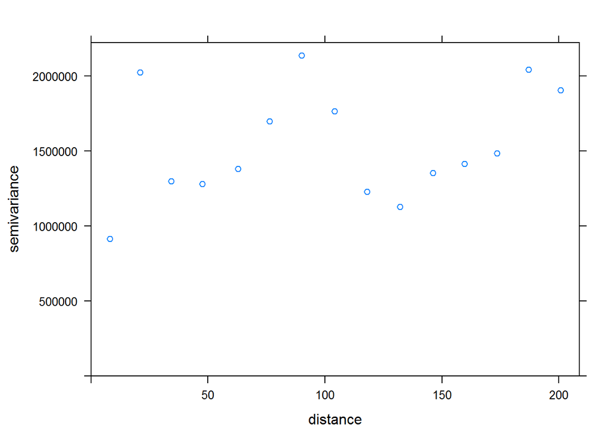

```r
  v <- variogram( y ~ 1, data = d[-test,]  )
  plot(v)
```

```r
  # this semi variogram does not appear to easily fit the mold
  mu <- fit.variogram(v,vgm(1, "Sph", 300, 1))
  gUK <- gstat(NULL, "y", y ~ elev, d[-test,], model = mu)

  # interpolate
  names(dem) <- 'elev'
  UK <- interpolate(dem, gUK, xyOnly = FALSE)
```

```
## [using universal kriging]
```

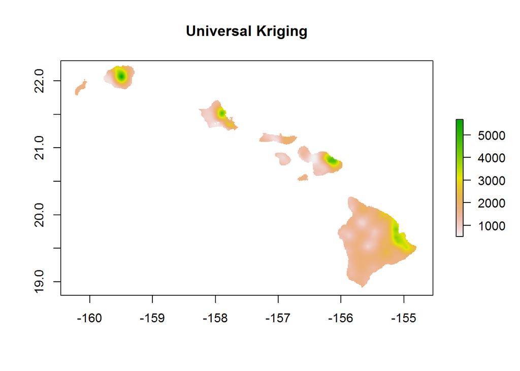

```r
  plot(UK, main = "Universal Kriging")
```

```r
  #evaluate
  UK.p <- predict(gUK, d[test,])
```

```
## [using universal kriging]
```

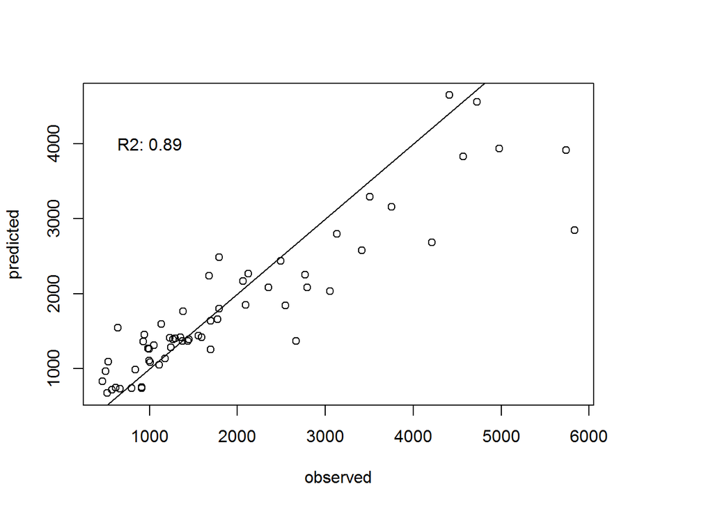

```r
  plot( y[test], UK.p$y.pred, xlab = 'observed', ylab = 'predicted');abline(0,1)
  UK.r2 <- round( cor(UK.p$y.pred, y[test])^2 , 2)
  text(1000, 4000, paste0('R2: ', tps.r2))
```

# Further Reading

[raster vignette](https://cran.r-project.org/web/packages/raster/vignettes/Raster.pdf) For a quick intro to manipulating raster data, including stacks and bricks [this excellent github site](https://pakillo.github.io/R-GIS-tutorial/) for using R as GIS